# Electricity Forecast

Damian Wisniewski

2023-08-08

## Electricity Price Analysis and Forecast

# Data

```r
# Using Martin Jummu's github repository to get the data
elprices <- readr::read_csv(
  "https://raw.githubusercontent.com/martinju/stromstotte/master/data/database_nordpool_daily.csv")
```

Data is updated on daily basis and contains following columns: - area: Price regions (NO1, NO2, …, NO5) - date - price: Daily average price in NOK per kWh

Data preperation

```r
# Filter out prices for Western Norway
westprices <- elprices |>
  filter(area == "NO5") |>
  select(-area) |>
  as_tsibble(index = date)

# Create a January test set
test <- westprices %>%
  filter(yearmonth(date) == yearmonth("Jan 2023"))

# Create our February forecasting set
feb23 <- westprices %>%
  filter(yearmonth(date) == yearmonth("Feb 2023"))

# Filter out prices before year 2023
westprices <- westprices %>%
  filter(year(date) < 2023)
```

## Exploratory Analysis

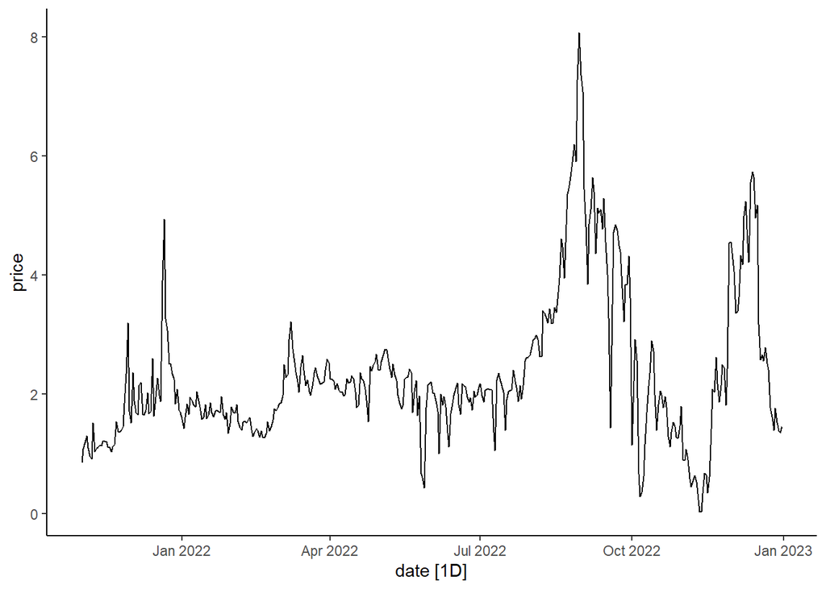

```r
# Plot of price
westprices|>
  autoplot(price)
```

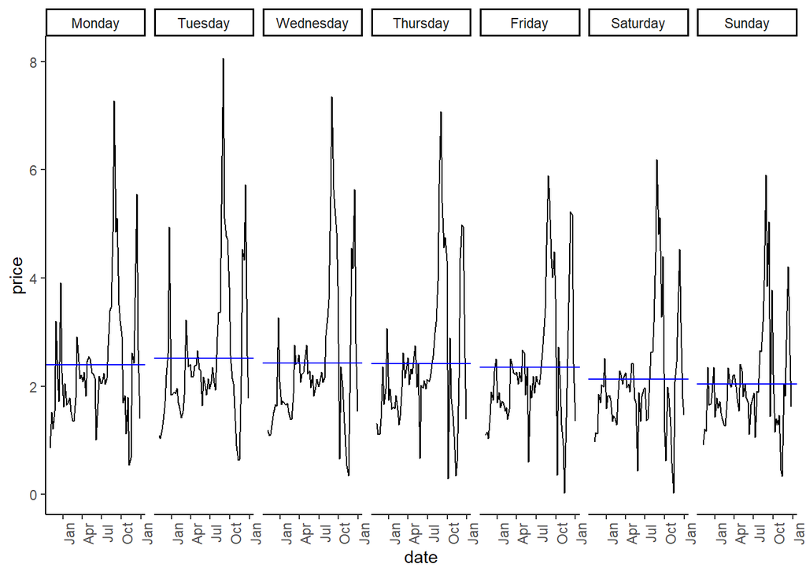

```r
#
westprices |>
  gg_subseries(price, period = "week")
```

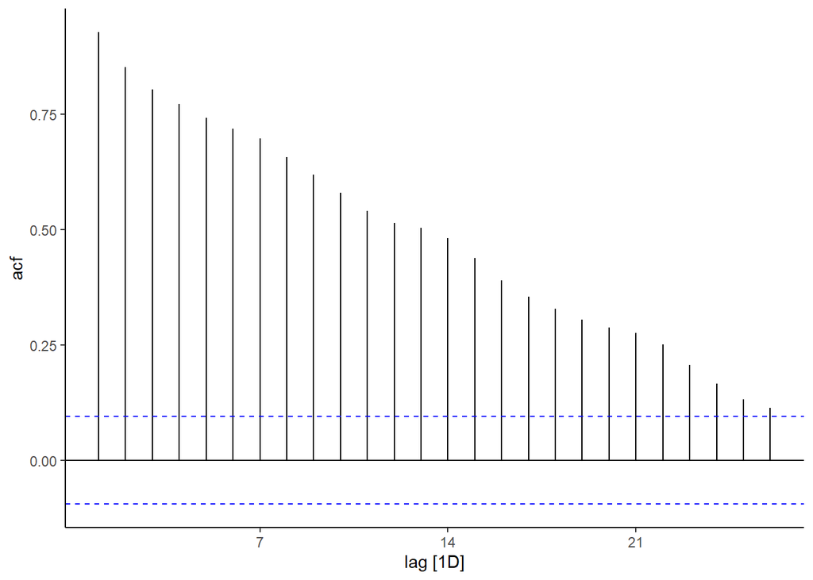

```r
westprices |>
  ACF(price) |>
  autoplot()
```

It is hard to detect any seasonal patterns from the time plot, but we can clearly see some cyclic behavoir in the price. We can however see that the average price is a bit lower on Staturday and Sunday in the seasonal subseries plot. We also see that the different days follow eachother over time in this plot. The ACF plot shows a slowly declining autocorrelation with very high correlation for the first lag. From this we can already see that maybe a ARIMA type model would be well suited for modelling this behavoir, because it seems that price on the days before is more important than the average price of a Sunday for instance.

## Decomposition analysis

With daily observations, the methods used by official statistical agencies are not relevant as they only allow for monthly or quarterly data. Therefore in this workshop we will use STL method.

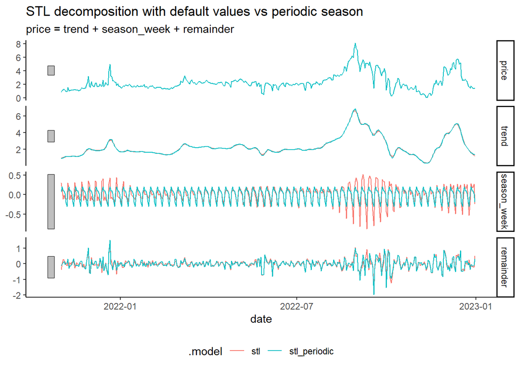

```r
westprices |>
  model(stl = STL(price ~season(period = "week")),
        stl_periodic = STL(price ~season(period = "week", window = "periodic"))) |>
  components() |>
  autoplot() +
  theme(legend.position = "bottom") +
  labs(title = "STL decomposition with default values vs periodic season")
```

# Modelling using ARIMA

In this section we want to tranform price variable to a stationary one that we can use for forcasting. We can do that using different methods; which we will do here and then later choose the most optimal one for forcasting.

```r
# Estimate lambda
lambda <- westprices |>
  features(price, guerrero) |>
  pull(lambda_guerrero)

cat("lambda = ", lambda)
```

```
## lambda =  0.5823901
```

Another transformation we can try are log and log(price + 1). Last one will allow for negative values of price, which can happen in case there is a surplus of electricity in the market.

Here we compare our transformations:

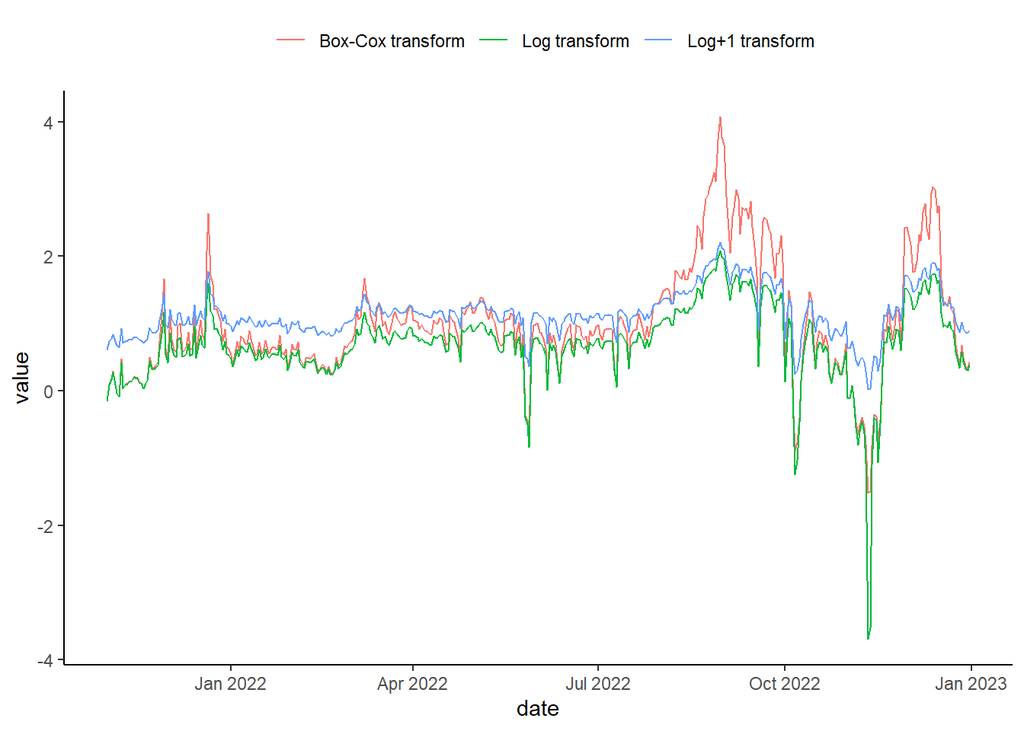

```r
# Plot of our transformations
westprices |>
  mutate("Box-Cox transform" = box_cox(price, lambda),
         "Log transform"     = log(price),
         "Log+1 transform"   = log(1 + price)) |>
  select(-price) |>
  pivot_longer(-date)  |>
  ggplot(aes(x=date, y = value)) +
  geom_line(aes(color = name)) +
  theme(legend.position = "top",
        legend.title = element_blank())
```

We can see that log(price + 1) seems like the most stable transformation and is potentially stationary such that we can use it for forecasting. We will therefore stick with this one for the rest of the project.

We will now check if this transformation is actually stationary.

```r
# Check for how many differences are needed for series to be stationary
westprices |>
  features(log(1 + price), unitroot_ndiffs)
```

```
## # A tibble: 1 × 1
##   ndiffs
##    <int>
## 1      1
```

```r
# and how many seasonal differences
westprices |>
  features(log(1 + price), unitroot_nsdiffs)
```

```
## # A tibble: 1 × 1
##   nsdiffs
##     <int>
## 1       0
```

We can see that we do not need seasonal differences, but we do need to do one first difference. We can double check if series is then stationary with tsdisplay plot:

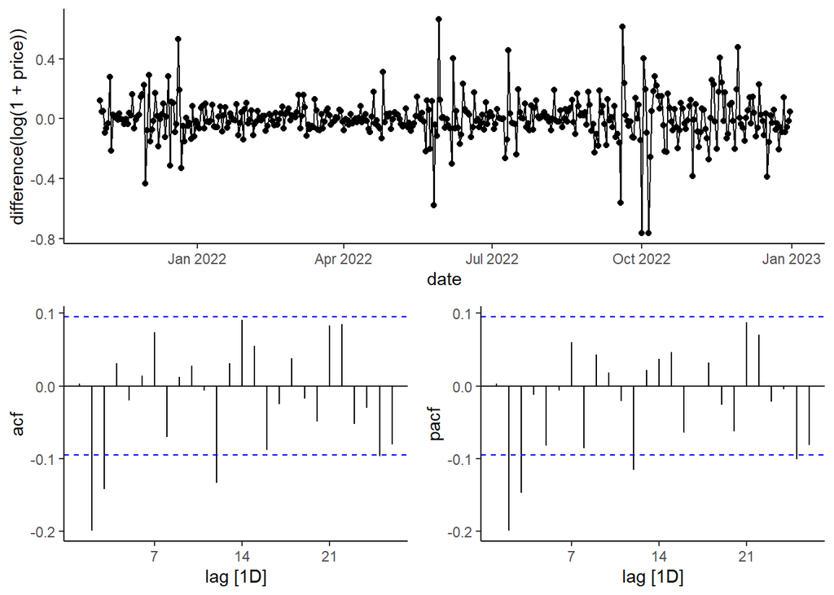

```r
# Check if differenced series is stationary
westprices |>
  gg_tsdisplay(difference(log(1 + price)), plot_type = "partial")
```

In the ACF plot above we have significant correlations at lag 2 and 3, which may suggest a AR(3) for the differenced series, i.e. ARIMA(3,1,0). The PACF also have sigificant correlations at lag 2 and 3, which may suggest MA(3) for the differenced series, i.e. ARIMA(0,1,3). We fit these two suggestions with the three automatic ones. I am also doing a full search for our specified models to look for seasonal terms.

```r
# Fitting our models
fits <- westprices |>
  model(
    ar   = ARIMA(log(1 + price) ~ pdq(3,1,0), stepwise = FALSE, approx = FALSE),
    ma   = ARIMA(log(1 + price) ~ pdq(0,1,3), stepwise = FALSE, approx = FALSE),
    stepwise = ARIMA(log(1 + price)),
    search = ARIMA(log(1 + price), stepwise = FALSE),
    auto   = ARIMA(log(1 + price), stepwise = FALSE, approx = FALSE)
  )

# Printing out model specifications
fits |>  pivot_longer(everything())
```

```
## # A mable: 5 x 2
## # Key:     name [5]
##   name                        value
##   <chr>                     <model>
## 1 ar       <ARIMA(3,1,0)(1,0,0)[7]>
## 2 ma       <ARIMA(0,1,3)(1,0,0)[7]>
## 3 stepwise <ARIMA(0,1,3)(0,0,1)[7]>
## 4 search   <ARIMA(0,1,3)(0,0,1)[7]>
## 5 auto     <ARIMA(0,1,3)(1,0,0)[7]>
```

We can see that ARIMA function has suggested including a seasonal AR term at lag 7 in our suggested AR and MA models. Furthermore we can see that the automated full grid search model agrees with our MA model.

Let’s check how our models performed in terms of AICc

```r
fits |>
  glance() |>
  arrange(AICc) |>
  select(.model:BIC)
```

```
## # A tibble: 5 × 6
##   .model   sigma2 log_lik   AIC  AICc   BIC
##   <chr>     <dbl>   <dbl> <dbl> <dbl> <dbl>
## 1 ma       0.0188    243. -476. -476. -456.
## 2 auto     0.0188    243. -476. -476. -456.
## 3 stepwise 0.0188    243. -476. -476. -456.
## 4 search   0.0188    243. -476. -476. -456.
## 5 ar       0.0189    243. -475. -475. -455.
```

Since the ma and auto options ended up with the same model, the AICc values will of course also be the same and it turns out this is the best model by AIC, AICc and BIC.

Let’s filter out our best model

```r
fit <- fits |>
  select(auto)
```

Let’s do some diagnostic of our model and it’s residuals to check forecasting assumptions.

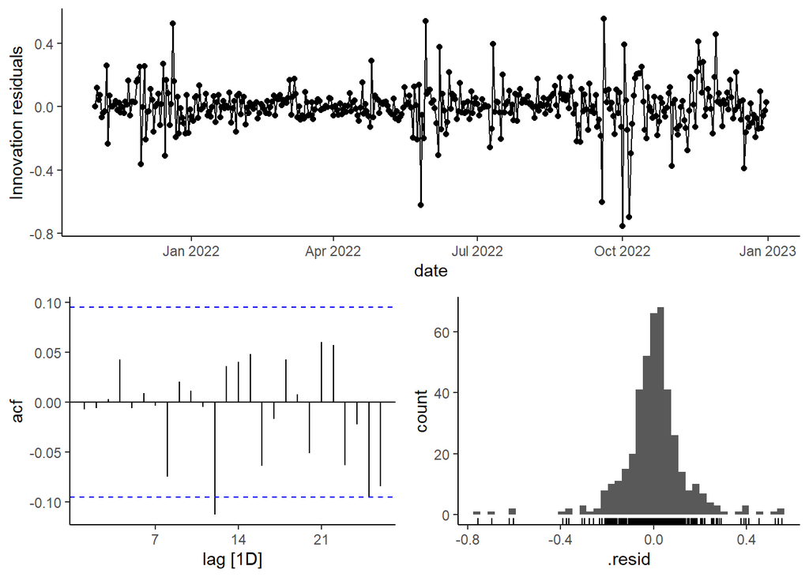

```r
fit |>
  gg_tsresiduals()
```

```r
fit |>
  augment() |>
  features(.innov, ljung_box, dof = 4, lag = 14)
```

```
## # A tibble: 1 × 3
##   .model lb_stat lb_pvalue
##   <chr>    <dbl>     <dbl>
## 1 auto      10.5     0.400
```

# Forecasting average monthly price

We will now set up a Monte Carlo simulation for forecasting the average monthly electricity price for February We simulate daily February prices. We generate 500 forecasts of length 28 days. Then calculate the monthly average for all 500 simulations, giving us a sample of monthly averages that we calculate mean, standard devation and lower and upper 2.5% and 97.5% percentiles for.

```r
westprices_jan <- bind_rows(westprices, test)

fit <- westprices_jan |>
  model(arima = ARIMA(log(1 + price) ~ pdq(0,1,3) + PDQ(1,0,0)))

# Simulate:
sims <- fit |>
  generate(h = 28, times = 500)

sims %>%
  index_by(month = ~ yearmonth(.)) |>
  group_by(.rep) |>
  # Calculate monthly average price for the simulations
  summarize(average = mean(.sim)) |>
  ungroup() |>
  # Monte Carlo estimates:
  summarize(
    mean = mean(average),
    sd   = sd(average),
    lwr  = quantile(average, prob = 0.025),
    upr  = quantile(average, prob = 0.975)
  )
```

```
## # A tsibble: 1 x 5 [?]
##      month  mean    sd   lwr   upr
##      <mth> <dbl> <dbl> <dbl> <dbl>
## 1 2023 Feb  1.50 0.733 0.402  3.16
```

In this final simulation we will start from Jan 31st of 2023 with the mean, standard deviation and 95% prediction interval from values above. Then we update our model with new daily observations. Continue adding days and updating the forecast until all days of February are observed.

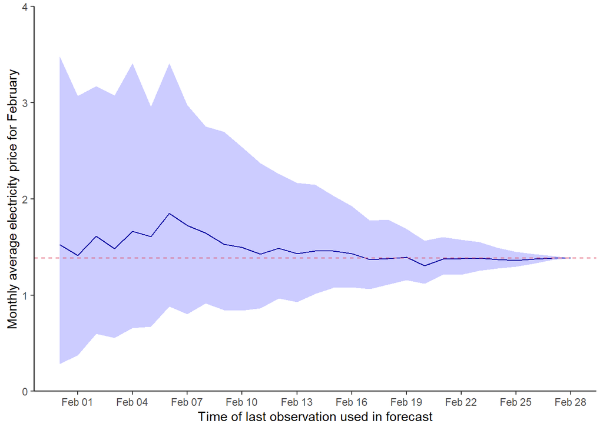

```r
train <- bind_rows(westprices_jan, feb23) |>
  stretch_tsibble(.init = nrow(westprices_jan), .step = 1)

avg.price <- tibble()

for(i in 1:29){
  ssum <- train |>
    filter(.id == i, yearmonth(date)==yearmonth("Feb 2023")) |>
    pull(price) |>
    sum()
  if(i < 29){
     fit <- train |> filter(.id == i) |>
       model(arima = ARIMA(log(1 + price) ~ pdq(0,1,3) + PDQ(1,0,0)))
     sims <-  fit |> generate(h = 29-i, times = 500) |>
      as_tibble() |>
      group_by(.rep) |>
      summarize(avg = (sum(.sim) + ssum) / 28) |>
      ungroup() |>
      summarize(
          mean = mean(avg),
          sd   = sd(avg),
          lwr  = quantile(avg, prob = 0.025),
          upr  = quantile(avg, prob = 0.975)
      )
  } else {
    sims = tibble(mean = ssum/28, sd = NA, lwr = ssum/28, upr = ssum/28)
  }
  avg.price <- bind_rows(avg.price, sims)
}

# Plot
avg.price |>
  mutate(date = seq(date("2023-01-31"), date("2023-02-28"), by = 1)) %>%
  ggplot(aes(x= date, y = mean, ymin= lwr, ymax = upr))+
  geom_line(color = "darkblue") +
  geom_ribbon(alpha = 0.2, fill = "blue") +
  scale_x_date(date_breaks = "3 days", date_labels = "%b %d")+
  scale_y_continuous(limits = c(0,4), expand = c(0,0))+
  geom_hline(yintercept = mean(feb23$price), lty = 2, col = 2)+
  labs(y = "Monthly average electricity price for February",
       x = "Time of last observation used in forecast")
```

The interpretation of the figure is that at the beginning of the month, we have little information and therefore quite large uncertainty: All the daily prices going into the monthly average have to be forecasted. But as time goes more and more of the daily prices are observed and fewer have to be forecasted. At say 25th of February we have observed 25 of the daily prices and only the remaining 3 are uncertain. Therefore the uncertainty is low. And at the 28th of February all daily prices are observed, and we know the monthly average price without uncertainty.